# Risk Factor Analysis

## Outcome Variable

**Outcome Variable:** ever_swasted

## Predictor Variables

**Intervention Variable:** birthlen

**Adjustment Set:**

- arm
- sex
- W_mage
- meducyrs
- feducyrs
- vagbrth
- single
- brthmon
- W_parity
- delta_W_mage
- delta_meducyrs
- delta_feducyrs
- delta_vagbrth
- delta_single
- delta_brthmon
- delta_W_parity

## Stratifying Variables

The analysis was stratified on these variable(s):

- agecat
- studyid
- country

## Data Summary

| agecat | studyid | country | birthlen | ever_swasted | n_cell | n |
| --- | --- | --- | --- | --- | --- | --- |
| 0-24 months (no birth wast) | CMC-V-BCS-2002 | INDIA | >=50 cm | 0 | 13 | 104 |
| 0-24 months (no birth wast) | CMC-V-BCS-2002 | INDIA | >=50 cm | 1 | 3 | 104 |
| 0-24 months (no birth wast) | CMC-V-BCS-2002 | INDIA | <48 cm | 0 | 36 | 104 |
| 0-24 months (no birth wast) | CMC-V-BCS-2002 | INDIA | <48 cm | 1 | 12 | 104 |
| 0-24 months (no birth wast) | CMC-V-BCS-2002 | INDIA | [48-50) cm | 0 | 34 | 104 |
| 0-24 months (no birth wast) | CMC-V-BCS-2002 | INDIA | [48-50) cm | 1 | 6 | 104 |
| 0-24 months (no birth wast) | CMIN | BANGLADESH | >=50 cm | 0 | 1 | 17 |
| 0-24 months (no birth wast) | CMIN | BANGLADESH | >=50 cm | 1 | 0 | 17 |
| 0-24 months (no birth wast) | CMIN | BANGLADESH | <48 cm | 0 | 8 | 17 |
| 0-24 months (no birth wast) | CMIN | BANGLADESH | <48 cm | 1 | 0 | 17 |
| 0-24 months (no birth wast) | CMIN | BANGLADESH | [48-50) cm | 0 | 8 | 17 |
| 0-24 months (no birth wast) | CMIN | BANGLADESH | [48-50) cm | 1 | 0 | 17 |
| 0-24 months (no birth wast) | COHORTS | GUATEMALA | >=50 cm | 0 | 418 | 821 |
| 0-24 months (no birth wast) | COHORTS | GUATEMALA | >=50 cm | 1 | 2 | 821 |
| 0-24 months (no birth wast) | COHORTS | GUATEMALA | <48 cm | 0 | 149 | 821 |
| 0-24 months (no birth wast) | COHORTS | GUATEMALA | <48 cm | 1 | 6 | 821 |
| 0-24 months (no birth wast) | COHORTS | GUATEMALA | [48-50) cm | 0 | 243 | 821 |
| 0-24 months (no birth wast) | COHORTS | GUATEMALA | [48-50) cm | 1 | 3 | 821 |
| 0-24 months (no birth wast) | COHORTS | INDIA | >=50 cm | 0 | 1349 | 6400 |
| 0-24 months (no birth wast) | COHORTS | INDIA | >=50 cm | 1 | 40 | 6400 |
| 0-24 months (no birth wast) | COHORTS | INDIA | <48 cm | 0 | 2473 | 6400 |
| 0-24 months (no birth wast) | COHORTS | INDIA | <48 cm | 1 | 171 | 6400 |
| 0-24 months (no birth wast) | COHORTS | INDIA | [48-50) cm | 0 | 2249 | 6400 |
| 0-24 months (no birth wast) | COHORTS | INDIA | [48-50) cm | 1 | 118 | 6400 |
| 0-24 months (no birth wast) | COHORTS | PHILIPPINES | >=50 cm | 0 | 1044 | 3011 |
| 0-24 months (no birth wast) | COHORTS | PHILIPPINES | >=50 cm | 1 | 77 | 3011 |
| 0-24 months (no birth wast) | COHORTS | PHILIPPINES | <48 cm | 0 | 674 | 3011 |
| 0-24 months (no birth wast) | COHORTS | PHILIPPINES | <48 cm | 1 | 66 | 3011 |
| 0-24 months (no birth wast) | COHORTS | PHILIPPINES | [48-50) cm | 0 | 1044 | 3011 |
| 0-24 months (no birth wast) | COHORTS | PHILIPPINES | [48-50) cm | 1 | 106 | 3011 |

[output cut: 438 more lines]

The following strata were considered:

- agecat: 0-24 months (no birth wast), studyid: CMC-V-BCS-2002, country: INDIA
- agecat: 0-24 months (no birth wast), studyid: CMIN, country: BANGLADESH
- agecat: 0-24 months (no birth wast), studyid: COHORTS, country: GUATEMALA
- agecat: 0-24 months (no birth wast), studyid: COHORTS, country: INDIA
- agecat: 0-24 months (no birth wast), studyid: COHORTS, country: PHILIPPINES
- agecat: 0-24 months (no birth wast), studyid: CONTENT, country: PERU
- agecat: 0-24 months (no birth wast), studyid: EE, country: PAKISTAN
- agecat: 0-24 months (no birth wast), studyid: GMS-Nepal, country: NEPAL
- agecat: 0-24 months (no birth wast), studyid: IRC, country: INDIA
- agecat: 0-24 months (no birth wast), studyid: JiVitA-3, country: BANGLADESH
- agecat: 0-24 months (no birth wast), studyid: JiVitA-4, country: BANGLADESH
- agecat: 0-24 months (no birth wast), studyid: Keneba, country: GAMBIA
- agecat: 0-24 months (no birth wast), studyid: MAL-ED, country: BANGLADESH
- agecat: 0-24 months (no birth wast), studyid: MAL-ED, country: BRAZIL
- agecat: 0-24 months (no birth wast), studyid: MAL-ED, country: INDIA
- agecat: 0-24 months (no birth wast), studyid: MAL-ED, country: NEPAL
- agecat: 0-24 months (no birth wast), studyid: MAL-ED, country: PERU
- agecat: 0-24 months (no birth wast), studyid: MAL-ED, country: SOUTH AFRICA
- agecat: 0-24 months (no birth wast), studyid: MAL-ED, country: TANZANIA, UNITED REPUBLIC OF
- agecat: 0-24 months (no birth wast), studyid: NIH-Birth, country: BANGLADESH
- agecat: 0-24 months (no birth wast), studyid: NIH-Crypto, country: BANGLADESH
- agecat: 0-24 months (no birth wast), studyid: PROBIT, country: BELARUS
- agecat: 0-24 months (no birth wast), studyid: PROVIDE, country: BANGLADESH
- agecat: 0-24 months (no birth wast), studyid: ResPak, country: PAKISTAN
- agecat: 0-24 months (no birth wast), studyid: SAS-CompFeed, country: INDIA
- agecat: 0-24 months (no birth wast), studyid: ZVITAMBO, country: ZIMBABWE
- agecat: 0-6 months (no birth wast), studyid: CMC-V-BCS-2002, country: INDIA
- agecat: 0-6 months (no birth wast), studyid: CMIN, country: BANGLADESH
- agecat: 0-6 months (no birth wast), studyid: COHORTS, country: GUATEMALA
- agecat: 0-6 months (no birth wast), studyid: COHORTS, country: INDIA
- agecat: 0-6 months (no birth wast), studyid: COHORTS, country: PHILIPPINES
- agecat: 0-6 months (no birth wast), studyid: CONTENT, country: PERU
- agecat: 0-6 months (no birth wast), studyid: EE, country: PAKISTAN
- agecat: 0-6 months (no birth wast), studyid: GMS-Nepal, country: NEPAL
- agecat: 0-6 months (no birth wast), studyid: IRC, country: INDIA
- agecat: 0-6 months (no birth wast), studyid: JiVitA-3, country: BANGLADESH
- agecat: 0-6 months (no birth wast), studyid: JiVitA-4, country: BANGLADESH
- agecat: 0-6 months (no birth wast), studyid: Keneba, country: GAMBIA
- agecat: 0-6 months (no birth wast), studyid: MAL-ED, country: BANGLADESH
- agecat: 0-6 months (no birth wast), studyid: MAL-ED, country: BRAZIL
- agecat: 0-6 months (no birth wast), studyid: MAL-ED, country: INDIA
- agecat: 0-6 months (no birth wast), studyid: MAL-ED, country: NEPAL
- agecat: 0-6 months (no birth wast), studyid: MAL-ED, country: PERU
- agecat: 0-6 months (no birth wast), studyid: MAL-ED, country: SOUTH AFRICA
- agecat: 0-6 months (no birth wast), studyid: MAL-ED, country: TANZANIA, UNITED REPUBLIC OF
- agecat: 0-6 months (no birth wast), studyid: NIH-Birth, country: BANGLADESH
- agecat: 0-6 months (no birth wast), studyid: NIH-Crypto, country: BANGLADESH
- agecat: 0-6 months (no birth wast), studyid: PROBIT, country: BELARUS
- agecat: 0-6 months (no birth wast), studyid: PROVIDE, country: BANGLADESH
- agecat: 0-6 months (no birth wast), studyid: ResPak, country: PAKISTAN
- agecat: 0-6 months (no birth wast), studyid: SAS-CompFeed, country: INDIA
- agecat: 0-6 months (no birth wast), studyid: ZVITAMBO, country: ZIMBABWE
- agecat: 6-24 months, studyid: CMC-V-BCS-2002, country: INDIA
- agecat: 6-24 months, studyid: CMIN, country: BANGLADESH
- agecat: 6-24 months, studyid: COHORTS, country: GUATEMALA
- agecat: 6-24 months, studyid: COHORTS, country: INDIA
- agecat: 6-24 months, studyid: COHORTS, country: PHILIPPINES
- agecat: 6-24 months, studyid: CONTENT, country: PERU
- agecat: 6-24 months, studyid: EE, country: PAKISTAN
- agecat: 6-24 months, studyid: GMS-Nepal, country: NEPAL
- agecat: 6-24 months, studyid: IRC, country: INDIA
- agecat: 6-24 months, studyid: JiVitA-3, country: BANGLADESH
- agecat: 6-24 months, studyid: JiVitA-4, country: BANGLADESH
- agecat: 6-24 months, studyid: Keneba, country: GAMBIA
- agecat: 6-24 months, studyid: MAL-ED, country: BANGLADESH
- agecat: 6-24 months, studyid: MAL-ED, country: BRAZIL
- agecat: 6-24 months, studyid: MAL-ED, country: INDIA
- agecat: 6-24 months, studyid: MAL-ED, country: NEPAL
- agecat: 6-24 months, studyid: MAL-ED, country: PERU
- agecat: 6-24 months, studyid: MAL-ED, country: SOUTH AFRICA
- agecat: 6-24 months, studyid: MAL-ED, country: TANZANIA, UNITED REPUBLIC OF
- agecat: 6-24 months, studyid: NIH-Birth, country: BANGLADESH
- agecat: 6-24 months, studyid: NIH-Crypto, country: BANGLADESH
- agecat: 6-24 months, studyid: PROBIT, country: BELARUS
- agecat: 6-24 months, studyid: PROVIDE, country: BANGLADESH
- agecat: 6-24 months, studyid: ResPak, country: PAKISTAN
- agecat: 6-24 months, studyid: SAS-CompFeed, country: INDIA
- agecat: 6-24 months, studyid: ZVITAMBO, country: ZIMBABWE

### Dropped Strata

Some strata were dropped due to rare outcomes:

- agecat: 0-24 months (no birth wast), studyid: CMC-V-BCS-2002, country: INDIA
- agecat: 0-24 months (no birth wast), studyid: CMIN, country: BANGLADESH
- agecat: 0-24 months (no birth wast), studyid: COHORTS, country: GUATEMALA
- agecat: 0-24 months (no birth wast), studyid: CONTENT, country: PERU
- agecat: 0-24 months (no birth wast), studyid: MAL-ED, country: BANGLADESH
- agecat: 0-24 months (no birth wast), studyid: MAL-ED, country: BRAZIL
- agecat: 0-24 months (no birth wast), studyid: MAL-ED, country: INDIA
- agecat: 0-24 months (no birth wast), studyid: MAL-ED, country: NEPAL
- agecat: 0-24 months (no birth wast), studyid: MAL-ED, country: PERU
- agecat: 0-24 months (no birth wast), studyid: MAL-ED, country: SOUTH AFRICA
- agecat: 0-24 months (no birth wast), studyid: MAL-ED, country: TANZANIA, UNITED REPUBLIC OF
- agecat: 0-24 months (no birth wast), studyid: NIH-Crypto, country: BANGLADESH
- agecat: 0-24 months (no birth wast), studyid: PROBIT, country: BELARUS
- agecat: 0-24 months (no birth wast), studyid: PROVIDE, country: BANGLADESH
- agecat: 0-24 months (no birth wast), studyid: ResPak, country: PAKISTAN
- agecat: 0-6 months (no birth wast), studyid: CMC-V-BCS-2002, country: INDIA
- agecat: 0-6 months (no birth wast), studyid: CMIN, country: BANGLADESH
- agecat: 0-6 months (no birth wast), studyid: COHORTS, country: GUATEMALA
- agecat: 0-6 months (no birth wast), studyid: CONTENT, country: PERU
- agecat: 0-6 months (no birth wast), studyid: EE, country: PAKISTAN
- agecat: 0-6 months (no birth wast), studyid: GMS-Nepal, country: NEPAL
- agecat: 0-6 months (no birth wast), studyid: JiVitA-4, country: BANGLADESH
- agecat: 0-6 months (no birth wast), studyid: MAL-ED, country: BANGLADESH
- agecat: 0-6 months (no birth wast), studyid: MAL-ED, country: BRAZIL
- agecat: 0-6 months (no birth wast), studyid: MAL-ED, country: INDIA
- agecat: 0-6 months (no birth wast), studyid: MAL-ED, country: NEPAL
- agecat: 0-6 months (no birth wast), studyid: MAL-ED, country: PERU
- agecat: 0-6 months (no birth wast), studyid: MAL-ED, country: SOUTH AFRICA
- agecat: 0-6 months (no birth wast), studyid: MAL-ED, country: TANZANIA, UNITED REPUBLIC OF
- agecat: 0-6 months (no birth wast), studyid: NIH-Birth, country: BANGLADESH
- agecat: 0-6 months (no birth wast), studyid: NIH-Crypto, country: BANGLADESH
- agecat: 0-6 months (no birth wast), studyid: PROBIT, country: BELARUS
- agecat: 0-6 months (no birth wast), studyid: PROVIDE, country: BANGLADESH
- agecat: 0-6 months (no birth wast), studyid: ResPak, country: PAKISTAN
- agecat: 0-6 months (no birth wast), studyid: SAS-CompFeed, country: INDIA
- agecat: 6-24 months, studyid: CMC-V-BCS-2002, country: INDIA
- agecat: 6-24 months, studyid: CMIN, country: BANGLADESH
- agecat: 6-24 months, studyid: COHORTS, country: GUATEMALA
- agecat: 6-24 months, studyid: CONTENT, country: PERU
- agecat: 6-24 months, studyid: EE, country: PAKISTAN
- agecat: 6-24 months, studyid: MAL-ED, country: BANGLADESH
- agecat: 6-24 months, studyid: MAL-ED, country: BRAZIL
- agecat: 6-24 months, studyid: MAL-ED, country: INDIA
- agecat: 6-24 months, studyid: MAL-ED, country: NEPAL
- agecat: 6-24 months, studyid: MAL-ED, country: PERU
- agecat: 6-24 months, studyid: MAL-ED, country: SOUTH AFRICA
- agecat: 6-24 months, studyid: MAL-ED, country: TANZANIA, UNITED REPUBLIC OF
- agecat: 6-24 months, studyid: NIH-Crypto, country: BANGLADESH
- agecat: 6-24 months, studyid: PROBIT, country: BELARUS
- agecat: 6-24 months, studyid: PROVIDE, country: BANGLADESH
- agecat: 6-24 months, studyid: ResPak, country: PAKISTAN

## Methods Detail

We’re interested in the causal parameters $E[Y_a]$ for all values of $a \in \mathcal{A}$. These parameters represent the mean outcome if, possibly contrary to fact, we intervened to set all units to have $A=a$. Under the randomization and positivity assumptions, these are identified by the statistical parameters $\psi_a=E_W[E_{Y|A,W}(Y|A=a,W)]$. In addition, we’re interested in the mean of $Y$, $E[Y]$ under no intervention (the observed mean). We will estimate these parameters by using SuperLearner to fit the relevant likelihood factors – $E_{Y|A,W}(Y|A=a,W)$ and $p(A=a|W)$, and then updating our likelihood fit using a joint TMLE.

For unadjusted analyses ($W=\{\}$), initial likelihoods were estimated using Lrnr_glm to estimate the simple $E(Y|A)$ and Lrnr_mean to estimate $p(A)$. For adjusted analyses, a small library containing Lrnr_glmnet, Lrnr_xgboost, and Lrnr_mean was used.

Having estimated these parameters, we will then use the delta method to estimate relative risks and attributable risks relative to a prespecified baseline level of $A$.

# Results Detail

## Results Plots

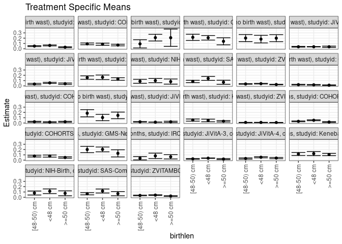

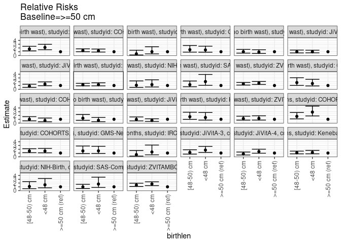

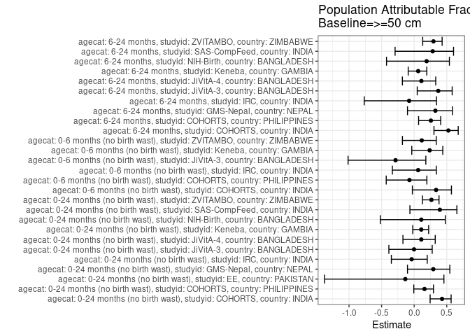

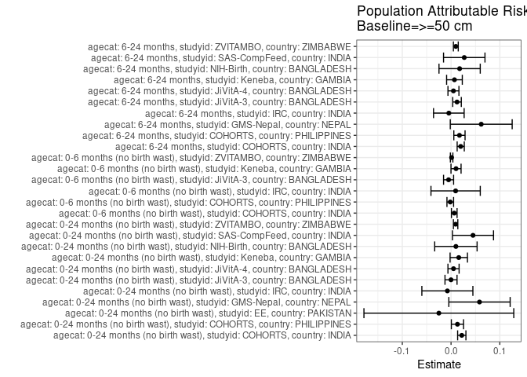

## Results Table

### Parameter: TSM

| agecat | studyid | country | intervention_level | baseline_level | estimate | ci_lower | ci_upper |
| --- | --- | --- | --- | --- | --- | --- | --- |
| 0-24 months (no birth wast) | COHORTS | INDIA | >=50 cm | NA | 0.0294089 | 0.0206708 | 0.0381469 |
| 0-24 months (no birth wast) | COHORTS | INDIA | <48 cm | NA | 0.0626722 | 0.0534095 | 0.0719349 |
| 0-24 months (no birth wast) | COHORTS | INDIA | [48-50) cm | NA | 0.0507404 | 0.0417815 | 0.0596993 |
| 0-24 months (no birth wast) | COHORTS | PHILIPPINES | >=50 cm | NA | 0.0695859 | 0.0545729 | 0.0845988 |
| 0-24 months (no birth wast) | COHORTS | PHILIPPINES | <48 cm | NA | 0.0866869 | 0.0665021 | 0.1068718 |
| 0-24 months (no birth wast) | COHORTS | PHILIPPINES | [48-50) cm | NA | 0.0927263 | 0.0758678 | 0.1095847 |
| 0-24 months (no birth wast) | EE | PAKISTAN | >=50 cm | NA | 0.2083333 | 0.0455164 | 0.3711503 |
| 0-24 months (no birth wast) | EE | PAKISTAN | <48 cm | NA | 0.2098765 | 0.1470379 | 0.2727152 |
| 0-24 months (no birth wast) | EE | PAKISTAN | [48-50) cm | NA | 0.0925926 | 0.0151202 | 0.1700650 |
| 0-24 months (no birth wast) | GMS-Nepal | NEPAL | >=50 cm | NA | 0.1404457 | 0.0737214 | 0.2071701 |
| 0-24 months (no birth wast) | GMS-Nepal | NEPAL | <48 cm | NA | 0.2072348 | 0.1648149 | 0.2496547 |
| 0-24 months (no birth wast) | GMS-Nepal | NEPAL | [48-50) cm | NA | 0.2156308 | 0.1577566 | 0.2735049 |
| 0-24 months (no birth wast) | IRC | INDIA | >=50 cm | NA | 0.1998407 | 0.1339610 | 0.2657204 |
| 0-24 months (no birth wast) | IRC | INDIA | <48 cm | NA | 0.1819744 | 0.1101968 | 0.2537520 |
| 0-24 months (no birth wast) | IRC | INDIA | [48-50) cm | NA | 0.2015986 | 0.1350045 | 0.2681927 |
| 0-24 months (no birth wast) | JiVitA-3 | BANGLADESH | >=50 cm | NA | 0.0378863 | 0.0250857 | 0.0506870 |
| 0-24 months (no birth wast) | JiVitA-3 | BANGLADESH | <48 cm | NA | 0.0379886 | 0.0346698 | 0.0413074 |
| 0-24 months (no birth wast) | JiVitA-3 | BANGLADESH | [48-50) cm | NA | 0.0376855 | 0.0310978 | 0.0442731 |
| 0-24 months (no birth wast) | JiVitA-4 | BANGLADESH | >=50 cm | NA | 0.0415215 | 0.0288312 | 0.0542119 |
| 0-24 months (no birth wast) | JiVitA-4 | BANGLADESH | <48 cm | NA | 0.0563796 | 0.0456120 | 0.0671473 |
| 0-24 months (no birth wast) | JiVitA-4 | BANGLADESH | [48-50) cm | NA | 0.0345634 | 0.0218947 | 0.0472321 |
| 0-24 months (no birth wast) | Keneba | GAMBIA | >=50 cm | NA | 0.1302691 | 0.1063382 | 0.1542001 |
| 0-24 months (no birth wast) | Keneba | GAMBIA | <48 cm | NA | 0.1624140 | 0.1195636 | 0.2052644 |
| 0-24 months (no birth wast) | Keneba | GAMBIA | [48-50) cm | NA | 0.1562879 | 0.1241729 | 0.1884029 |
| 0-24 months (no birth wast) | NIH-Birth | BANGLADESH | >=50 cm | NA | 0.0812922 | 0.0329468 | 0.1296376 |
| 0-24 months (no birth wast) | NIH-Birth | BANGLADESH | <48 cm | NA | 0.1003034 | 0.0609892 | 0.1396175 |
| 0-24 months (no birth wast) | NIH-Birth | BANGLADESH | [48-50) cm | NA | 0.0867862 | 0.0495847 | 0.1239878 |
| 0-24 months (no birth wast) | SAS-CompFeed | INDIA | >=50 cm | NA | 0.0691592 | 0.0305706 | 0.1077478 |
| 0-24 months (no birth wast) | SAS-CompFeed | INDIA | <48 cm | NA | 0.1409706 | 0.1039073 | 0.1780338 |
| 0-24 months (no birth wast) | SAS-CompFeed | INDIA | [48-50) cm | NA | 0.0838432 | 0.0618113 | 0.1058751 |

[output cut: 51 more lines]

### Parameter: E(Y)

| agecat | studyid | country | intervention_level | baseline_level | estimate | ci_lower | ci_upper |
| --- | --- | --- | --- | --- | --- | --- | --- |
| 0-24 months (no birth wast) | COHORTS | INDIA | NA | NA | 0.0514063 | 0.0459957 | 0.0568168 |
| 0-24 months (no birth wast) | COHORTS | PHILIPPINES | NA | NA | 0.0826968 | 0.0728574 | 0.0925361 |
| 0-24 months (no birth wast) | EE | PAKISTAN | NA | NA | 0.1833333 | 0.1342773 | 0.2323893 |
| 0-24 months (no birth wast) | GMS-Nepal | NEPAL | NA | NA | 0.1987860 | 0.1682929 | 0.2292792 |
| 0-24 months (no birth wast) | IRC | INDIA | NA | NA | 0.1923077 | 0.1531430 | 0.2314724 |
| 0-24 months (no birth wast) | JiVitA-3 | BANGLADESH | NA | NA | 0.0377996 | 0.0348944 | 0.0407048 |
| 0-24 months (no birth wast) | JiVitA-4 | BANGLADESH | NA | NA | 0.0465950 | 0.0398949 | 0.0532951 |
| 0-24 months (no birth wast) | Keneba | GAMBIA | NA | NA | 0.1460892 | 0.1284833 | 0.1636951 |
| 0-24 months (no birth wast) | NIH-Birth | BANGLADESH | NA | NA | 0.0912220 | 0.0677898 | 0.1146542 |
| 0-24 months (no birth wast) | SAS-CompFeed | INDIA | NA | NA | 0.1141706 | 0.0903032 | 0.1380379 |
| 0-24 months (no birth wast) | ZVITAMBO | ZIMBABWE | NA | NA | 0.0352566 | 0.0321456 | 0.0383677 |
| 0-6 months (no birth wast) | COHORTS | INDIA | NA | NA | 0.0194977 | 0.0160139 | 0.0229815 |
| 0-6 months (no birth wast) | COHORTS | PHILIPPINES | NA | NA | 0.0220736 | 0.0168064 | 0.0273407 |
| 0-6 months (no birth wast) | IRC | INDIA | NA | NA | 0.1532258 | 0.1165727 | 0.1898789 |
| 0-6 months (no birth wast) | JiVitA-3 | BANGLADESH | NA | NA | 0.0177215 | 0.0156439 | 0.0197992 |
| 0-6 months (no birth wast) | Keneba | GAMBIA | NA | NA | 0.0430528 | 0.0328889 | 0.0532168 |
| 0-6 months (no birth wast) | ZVITAMBO | ZIMBABWE | NA | NA | 0.0099593 | 0.0082687 | 0.0116498 |
| 6-24 months | COHORTS | INDIA | NA | NA | 0.0377695 | 0.0330119 | 0.0425271 |
| 6-24 months | COHORTS | PHILIPPINES | NA | NA | 0.0670949 | 0.0578297 | 0.0763601 |
| 6-24 months | GMS-Nepal | NEPAL | NA | NA | 0.1901528 | 0.1584343 | 0.2218713 |
| 6-24 months | IRC | INDIA | NA | NA | 0.0588235 | 0.0354714 | 0.0821757 |
| 6-24 months | JiVitA-3 | BANGLADESH | NA | NA | 0.0331237 | 0.0300503 | 0.0361971 |
| 6-24 months | JiVitA-4 | BANGLADESH | NA | NA | 0.0442557 | 0.0375111 | 0.0510003 |
| 6-24 months | Keneba | GAMBIA | NA | NA | 0.1129792 | 0.0968836 | 0.1290747 |
| 6-24 months | NIH-Birth | BANGLADESH | NA | NA | 0.0919540 | 0.0671416 | 0.1167664 |
| 6-24 months | SAS-CompFeed | INDIA | NA | NA | 0.0952035 | 0.0698704 | 0.1205365 |
| 6-24 months | ZVITAMBO | ZIMBABWE | NA | NA | 0.0331151 | 0.0297229 | 0.0365072 |

### Parameter: RR

| agecat | studyid | country | intervention_level | baseline_level | estimate | ci_lower | ci_upper |
| --- | --- | --- | --- | --- | --- | --- | --- |
| 0-24 months (no birth wast) | COHORTS | INDIA | >=50 cm | >=50 cm | 1.0000000 | 1.0000000 | 1.000000 |
| 0-24 months (no birth wast) | COHORTS | INDIA | <48 cm | >=50 cm | 2.1310649 | 1.5295141 | 2.969203 |
| 0-24 months (no birth wast) | COHORTS | INDIA | [48-50) cm | >=50 cm | 1.7253443 | 1.2214735 | 2.437067 |
| 0-24 months (no birth wast) | COHORTS | PHILIPPINES | >=50 cm | >=50 cm | 1.0000000 | 1.0000000 | 1.000000 |
| 0-24 months (no birth wast) | COHORTS | PHILIPPINES | <48 cm | >=50 cm | 1.2457548 | 0.9075115 | 1.710066 |
| 0-24 months (no birth wast) | COHORTS | PHILIPPINES | [48-50) cm | >=50 cm | 1.3325447 | 1.0054150 | 1.766112 |
| 0-24 months (no birth wast) | EE | PAKISTAN | >=50 cm | >=50 cm | 1.0000000 | 1.0000000 | 1.000000 |
| 0-24 months (no birth wast) | EE | PAKISTAN | <48 cm | >=50 cm | 1.0074074 | 0.4362537 | 2.326329 |
| 0-24 months (no birth wast) | EE | PAKISTAN | [48-50) cm | >=50 cm | 0.4444444 | 0.1414439 | 1.396532 |
| 0-24 months (no birth wast) | GMS-Nepal | NEPAL | >=50 cm | >=50 cm | 1.0000000 | 1.0000000 | 1.000000 |
| 0-24 months (no birth wast) | GMS-Nepal | NEPAL | <48 cm | >=50 cm | 1.4755508 | 0.8794935 | 2.475573 |
| 0-24 months (no birth wast) | GMS-Nepal | NEPAL | [48-50) cm | >=50 cm | 1.5353316 | 0.8897227 | 2.649413 |
| 0-24 months (no birth wast) | IRC | INDIA | >=50 cm | >=50 cm | 1.0000000 | 1.0000000 | 1.000000 |
| 0-24 months (no birth wast) | IRC | INDIA | <48 cm | >=50 cm | 0.9105973 | 0.5450338 | 1.521351 |
| 0-24 months (no birth wast) | IRC | INDIA | [48-50) cm | >=50 cm | 1.0087966 | 0.6319430 | 1.610383 |
| 0-24 months (no birth wast) | JiVitA-3 | BANGLADESH | >=50 cm | >=50 cm | 1.0000000 | 1.0000000 | 1.000000 |
| 0-24 months (no birth wast) | JiVitA-3 | BANGLADESH | <48 cm | >=50 cm | 1.0027001 | 0.7095480 | 1.416969 |
| 0-24 months (no birth wast) | JiVitA-3 | BANGLADESH | [48-50) cm | >=50 cm | 0.9946982 | 0.6863267 | 1.441623 |
| 0-24 months (no birth wast) | JiVitA-4 | BANGLADESH | >=50 cm | >=50 cm | 1.0000000 | 1.0000000 | 1.000000 |
| 0-24 months (no birth wast) | JiVitA-4 | BANGLADESH | <48 cm | >=50 cm | 1.3578409 | 0.9428057 | 1.955580 |
| 0-24 months (no birth wast) | JiVitA-4 | BANGLADESH | [48-50) cm | >=50 cm | 0.8324210 | 0.5152375 | 1.344865 |
| 0-24 months (no birth wast) | Keneba | GAMBIA | >=50 cm | >=50 cm | 1.0000000 | 1.0000000 | 1.000000 |
| 0-24 months (no birth wast) | Keneba | GAMBIA | <48 cm | >=50 cm | 1.2467573 | 0.9045634 | 1.718402 |
| 0-24 months (no birth wast) | Keneba | GAMBIA | [48-50) cm | >=50 cm | 1.1997311 | 0.9105703 | 1.580718 |
| 0-24 months (no birth wast) | NIH-Birth | BANGLADESH | >=50 cm | >=50 cm | 1.0000000 | 1.0000000 | 1.000000 |
| 0-24 months (no birth wast) | NIH-Birth | BANGLADESH | <48 cm | >=50 cm | 1.2338622 | 0.6060461 | 2.512047 |
| 0-24 months (no birth wast) | NIH-Birth | BANGLADESH | [48-50) cm | >=50 cm | 1.0675837 | 0.5141549 | 2.216715 |
| 0-24 months (no birth wast) | SAS-CompFeed | INDIA | >=50 cm | >=50 cm | 1.0000000 | 1.0000000 | 1.000000 |
| 0-24 months (no birth wast) | SAS-CompFeed | INDIA | <48 cm | >=50 cm | 2.0383487 | 1.0577109 | 3.928167 |
| 0-24 months (no birth wast) | SAS-CompFeed | INDIA | [48-50) cm | >=50 cm | 1.2123216 | 0.6711113 | 2.189985 |

[output cut: 51 more lines]

### Parameter: PAR

| agecat | studyid | country | intervention_level | baseline_level | estimate | ci_lower | ci_upper |
| --- | --- | --- | --- | --- | --- | --- | --- |
| 0-24 months (no birth wast) | COHORTS | INDIA | >=50 cm | NA | 0.0219974 | 0.0134966 | 0.0304982 |
| 0-24 months (no birth wast) | COHORTS | PHILIPPINES | >=50 cm | NA | 0.0131109 | 0.0005977 | 0.0256242 |
| 0-24 months (no birth wast) | EE | PAKISTAN | >=50 cm | NA | -0.0250000 | -0.1786684 | 0.1286684 |
| 0-24 months (no birth wast) | GMS-Nepal | NEPAL | >=50 cm | NA | 0.0583403 | -0.0045545 | 0.1212352 |
| 0-24 months (no birth wast) | IRC | INDIA | >=50 cm | NA | -0.0075330 | -0.0598672 | 0.0448012 |
| 0-24 months (no birth wast) | JiVitA-3 | BANGLADESH | >=50 cm | NA | -0.0000867 | -0.0124319 | 0.0122584 |
| 0-24 months (no birth wast) | JiVitA-4 | BANGLADESH | >=50 cm | NA | 0.0050734 | -0.0063751 | 0.0165219 |
| 0-24 months (no birth wast) | Keneba | GAMBIA | >=50 cm | NA | 0.0158201 | -0.0019947 | 0.0336349 |
| 0-24 months (no birth wast) | NIH-Birth | BANGLADESH | >=50 cm | NA | 0.0099298 | -0.0335388 | 0.0533985 |
| 0-24 months (no birth wast) | SAS-CompFeed | INDIA | >=50 cm | NA | 0.0450114 | 0.0029031 | 0.0871197 |
| 0-24 months (no birth wast) | ZVITAMBO | ZIMBABWE | >=50 cm | NA | 0.0093363 | 0.0048014 | 0.0138712 |
| 0-6 months (no birth wast) | COHORTS | INDIA | >=50 cm | NA | 0.0065602 | 0.0007829 | 0.0123374 |
| 0-6 months (no birth wast) | COHORTS | PHILIPPINES | >=50 cm | NA | -0.0016064 | -0.0084105 | 0.0051978 |
| 0-6 months (no birth wast) | IRC | INDIA | >=50 cm | NA | 0.0093749 | -0.0411895 | 0.0599393 |
| 0-6 months (no birth wast) | JiVitA-3 | BANGLADESH | >=50 cm | NA | -0.0050718 | -0.0153816 | 0.0052381 |
| 0-6 months (no birth wast) | Keneba | GAMBIA | >=50 cm | NA | 0.0102109 | -0.0001151 | 0.0205368 |
| 0-6 months (no birth wast) | ZVITAMBO | ZIMBABWE | >=50 cm | NA | 0.0011571 | -0.0013991 | 0.0037133 |
| 6-24 months | COHORTS | INDIA | >=50 cm | NA | 0.0198211 | 0.0125285 | 0.0271137 |
| 6-24 months | COHORTS | PHILIPPINES | >=50 cm | NA | 0.0172097 | 0.0056973 | 0.0287221 |
| 6-24 months | GMS-Nepal | NEPAL | >=50 cm | NA | 0.0618829 | -0.0015957 | 0.1253614 |
| 6-24 months | IRC | INDIA | >=50 cm | NA | -0.0045568 | -0.0359562 | 0.0268427 |
| 6-24 months | JiVitA-3 | BANGLADESH | >=50 cm | NA | 0.0122411 | 0.0034717 | 0.0210105 |
| 6-24 months | JiVitA-4 | BANGLADESH | >=50 cm | NA | 0.0049085 | -0.0063378 | 0.0161548 |
| 6-24 months | Keneba | GAMBIA | >=50 cm | NA | 0.0069685 | -0.0091180 | 0.0230549 |
| 6-24 months | NIH-Birth | BANGLADESH | >=50 cm | NA | 0.0175739 | -0.0247385 | 0.0598862 |
| 6-24 months | SAS-CompFeed | INDIA | >=50 cm | NA | 0.0270813 | -0.0154109 | 0.0695734 |
| 6-24 months | ZVITAMBO | ZIMBABWE | >=50 cm | NA | 0.0097874 | 0.0047921 | 0.0147827 |

### Parameter: PAF

| agecat | studyid | country | intervention_level | baseline_level | estimate | ci_lower | ci_upper |
| --- | --- | --- | --- | --- | --- | --- | --- |
| 0-24 months (no birth wast) | COHORTS | INDIA | >=50 cm | NA | 0.4279127 | 0.2445576 | 0.5667653 |
| 0-24 months (no birth wast) | COHORTS | PHILIPPINES | >=50 cm | NA | 0.1585421 | -0.0060677 | 0.2962189 |
| 0-24 months (no birth wast) | EE | PAKISTAN | >=50 cm | NA | -0.1363636 | -1.3752424 | 0.4563408 |
| 0-24 months (no birth wast) | GMS-Nepal | NEPAL | >=50 cm | NA | 0.2934830 | -0.1026759 | 0.5473137 |
| 0-24 months (no birth wast) | IRC | INDIA | >=50 cm | NA | -0.0391715 | -0.3502498 | 0.2002388 |
| 0-24 months (no birth wast) | JiVitA-3 | BANGLADESH | >=50 cm | NA | -0.0022947 | -0.3883717 | 0.2764224 |
| 0-24 months (no birth wast) | JiVitA-4 | BANGLADESH | >=50 cm | NA | 0.1088840 | -0.1726815 | 0.3228445 |
| 0-24 months (no birth wast) | Keneba | GAMBIA | >=50 cm | NA | 0.1082905 | -0.0218824 | 0.2218813 |
| 0-24 months (no birth wast) | NIH-Birth | BANGLADESH | >=50 cm | NA | 0.1088534 | -0.5201883 | 0.4776027 |
| 0-24 months (no birth wast) | SAS-CompFeed | INDIA | >=50 cm | NA | 0.3942467 | -0.0654438 | 0.6556017 |
| 0-24 months (no birth wast) | ZVITAMBO | ZIMBABWE | >=50 cm | NA | 0.2648099 | 0.1266796 | 0.3810926 |
| 0-6 months (no birth wast) | COHORTS | INDIA | >=50 cm | NA | 0.3364589 | -0.0278075 | 0.5716253 |
| 0-6 months (no birth wast) | COHORTS | PHILIPPINES | >=50 cm | NA | -0.0727741 | -0.4292859 | 0.1948117 |
| 0-6 months (no birth wast) | IRC | INDIA | >=50 cm | NA | 0.0611837 | -0.3348064 | 0.3396975 |
| 0-6 months (no birth wast) | JiVitA-3 | BANGLADESH | >=50 cm | NA | -0.2861917 | -1.0147986 | 0.1789308 |
| 0-6 months (no birth wast) | Keneba | GAMBIA | >=50 cm | NA | 0.2371711 | -0.0370087 | 0.4388591 |
| 0-6 months (no birth wast) | ZVITAMBO | ZIMBABWE | >=50 cm | NA | 0.1161823 | -0.1806138 | 0.3383665 |
| 6-24 months | COHORTS | INDIA | >=50 cm | NA | 0.5247915 | 0.3035980 | 0.6757288 |
| 6-24 months | COHORTS | PHILIPPINES | >=50 cm | NA | 0.2564979 | 0.0678022 | 0.4069977 |
| 6-24 months | GMS-Nepal | NEPAL | >=50 cm | NA | 0.3254376 | -0.1026603 | 0.5873304 |
| 6-24 months | IRC | INDIA | >=50 cm | NA | -0.0774648 | -0.7670506 | 0.3430124 |
| 6-24 months | JiVitA-3 | BANGLADESH | >=50 cm | NA | 0.3695580 | 0.0465987 | 0.5831167 |
| 6-24 months | JiVitA-4 | BANGLADESH | >=50 cm | NA | 0.1109120 | -0.1811512 | 0.3307567 |
| 6-24 months | Keneba | GAMBIA | >=50 cm | NA | 0.0616794 | -0.0918334 | 0.1936082 |
| 6-24 months | NIH-Birth | BANGLADESH | >=50 cm | NA | 0.1911157 | -0.4244304 | 0.5406628 |
| 6-24 months | SAS-CompFeed | INDIA | >=50 cm | NA | 0.2844565 | -0.2932542 | 0.6040976 |
| 6-24 months | ZVITAMBO | ZIMBABWE | >=50 cm | NA | 0.2955574 | 0.1309585 | 0.4289808 |